# Cover Page

**Title**

Kelp Forest Fish Length Manuscript

**Authors**

Juan Carlos Villaseñor-Derbez$^{1, 2}$, C. Gabriela Montaño-Moctezuma$^3$, Guillermo Torres-Moye$^1$, Antonio Trujillo-Ortiz$^1$, Arturo Ramírez-Valdez$^{1, 4}$

**Adscriptions**

1. Facultad de Ciencias Marinas, Universidad Autónoma de Baja California, Km. 103 Carretera Tijuana-Ensenada, Ensenada, Baja California, México C.P. 22860
2. Bren School of Environmental Science & Management, University of California Santa Barbara, Santa Barbara, CA
3. Instituto de Investigaciones Oceanológicas, Universidad Autónoma de Baja California, Km. 103 Carretera Tijuana-Ensenada, Ensenada, Baja California, México C.P. 22860
4. Scripps Institution of Oceanography, University of California San Diego, La Jolla, CA, USA

**Corresponding Author**

Juan Carlos Villaseñor-Derbez, (+1) 207 205 8435, jvillasenor@bren.ucsb.edu

# Abstract

# Key words

# Introduction

Removing organisms of specific sizes (size-selective harvesting) is common in marine and terrestrial ecosystems (Fenberg & Roy, 2008). Commercial fisheries often focus their efforts on large-size organisms within a same species which often represents a greater revenue-effort ratio (Hepell et al., 2005; Hamilton et al., 2007). Sport-fishing follows the same pattern, as larger fish represent a greater challenge and thus produce more satisfaction when captured (Shroeder & Love, 2002). Size-selective harvesting can also be market-driven when stakeholders have a preferred size, typically medium-sized or “dish-sized” fish that can be better allocated in the market (Reddy et al., 2013).

Fish populations are heavily influenced by size-selective harvesting. On a scenario without fishing pressure, populations present different size distributions that respond to local factors (e.g. food availability or mortality). Nevertheless, when mortality is higher for specific size intervals (i.e. size-selective harvesting), life histories (Hepell et al., 2005), phenotypic plasticity (Brown & Parman, 1993; Fenberg & Roy, 2008), and size structures (Hamilton et al., 2007) will be modified.

For example, Thompson & Stokes (1996) demonstrated how different fishing methods targeting different sizes produced different size structures on Atlantic cod (Gadus morhua) populations by non-randomly distributing mortality. Off the coasts of California, Young (1963) and Love et al. (1996) studied aspects of the life history of the kelp bass (Paralabrax clathratus). In the time between their studies, size-at-maturity of this species decreased by 4 cm, likely as a response to heavy fishing pressure. Hamilton et al., (2007) identified that males and females of the California Sheephead (Semicossyphus pulcher; a female-male sex changing species) matured earlier and changed sex both at smaller sizes and younger ages. Thus, it is evident that fishing pressure (especially when size-selective) can modify life histories of fishes (McBride et al., 2013).

Kelp forests distributed along the Eastern Pacific coast are transboundary resources (Torres-Moye et al., 2013), and thus pose particular managing challenges. Resources associated to kelp forests on Mexican coasts have received little attention when compared to their homologous across the border. Macroalgae and invertebrates have been widely studied (e.g. Ladah et al., 1999; Torres-Moye et al., 2013), but few work has been done towards assessing finfish resources and fishing activities (Hamilton et al., 2007; Sosa-Nishizaki et al., 2013). Thus, the only available information about size structures for fish populations comes from landing reports that do not necessarily reflect the composition and state of populations as the indicators (e.g. size structure) may be biased by the interests of fisheries operating in each region (Essington et al., 2006). This lack of information impairs decision making and disables the implementation of correct management strategies.

Given the importance of size structures for fish populations, we aimed to evaluate the differences in size structures of fish populations across Baja California (only targeted species), and interpret them in the context of anthropogenic stressors (human population density and fishing pressure). Specifically, we compared size structures, fish size, and proportion of potentially mature organisms of fish populations under different degrees of anthropogenic pressure. This study represents the first approach to comprehensively assess fish size-structures and densities along the Mexican kelp forests through visual censuses and that did not rely on landing data.

```r
suppressPackageStartupMessages({
  library(sp)
  library(tmap)
  library(rgdal)
  library(raster)
  library(maptools)
  library(tidyverse)
  library(tmaptools)
  library(MPAtools)
})
```

```r
#Site Metadata
site_metadata <- read.csv("../Data/site_metadata.csv", stringsAsFactors = F) %>%
  dplyr::select(Location, Latitude, Longitude, Latitudinal.distance..km.) %>%
  rename(LatDist = Latitudinal.distance..km.,
         Site = Location) %>%
  group_by(Site) %>%
  summarize(Latitude = mean(Latitude),
            Longitude = mean(Longitude),
            LatDist = mean(LatDist))
#Kelp density data
kelp_data <- read.csv("../Data/Tidy/KelpAbundances.csv", stringsAsFactors = F, strip.white = T) %>%
  mutate(KelpDensity = Algae / Transects) %>%
  dplyr::select(Site, KelpDensity)
#abnt data
load("../../MPAtools/data/abnt.RData")
abnt <- rename(abnt, GenusSpecies = GeneroEspecie, A = a, B =b)
length_data <- read.csv("../Data/Tidy/tidy_data.csv", stringsAsFactors = F) %>%
  left_join(site_metadata, by = "Site") %>%
  left_join(kelp_data, by = "Site") %>%
  left_join(abnt, by = "GenusSpecies") %>%
  dplyr::select(ID, Site, Zone, Latitude, Longitude, LatDist, KelpDensity, Habitat, Transect, GenusSpecies, Length, Abundance, a = A, b = B, NT, Lm, Lmax, Lm_estimate)
```

```r
# set a working directory for spatial datasets
dir = "../Data/Spatial"
# load the state shapefile
stat <- readOGR(dsn = dir, layer = "states", verbose = F)
# Define peninsula shapefile
baja <- stat[stat$NAME %in% c("Baja California Norte", "Baja California Sur", "Sonora", "Sinaloa"),]
# Define Baja Norte shapefile
baja_norte <- stat[stat$NAME == "Baja California Norte",]
# Define the coordenate reference system
proj <- CRS("+proj=lcc +lat_1=17.5 +lat_2=29.5 +lat_0=0 +lon_0=-102 +x_0=2000000 +y_0=0 +datum=NAD27 +units=m +no_defs +ellps=clrk66 +nadgrids=@conus,@alaska,@ntv2_0.gsb,@ntv1_can.dat")
proj2 <- CRS("+proj=longlat +datum=NAD27")
#convert the spatial points in length data to shapefile
xy <- data.frame(X = length_data$Longitude, Y = length_data$Latitude)
coordinates(xy) <- c("X", "Y")
proj4string(xy) <- proj2  ## for example
res <- spTransform(xy, proj2)
b <- SpatialPointsDataFrame(coords = res, data = length_data, proj4string = proj2)
```

# Methods

## Area of study

The present study took place on the kelp forests off the coasts of Baja California, Mexico (Fig. 1). Kelp forests are among the most productive environments on the planet (Man, 1973, Steneck et al., 2002) and sustain large populations of commercially important fish, invertebrates and algae (Erlandson, 2001). Fishing has been recognized as one of the most important sources of pressure exerted on kelp forests (Shroeder & Love, 2002; Coleman et al., 2003). For the area of study, an average sport-fishing trip may yield a catch of 19 organisms, equivalent to 54 Kg (Sosa-Nishizaki et al., 2013).

Human population is unequally distributed along Baja California. The larger cities on the Pacific coast of the state (Tijuana and Ensenada) are located in the north, and there are vast unpopulated areas towards the south. Fishing pressure (commercial and artisanal) is heterogeneously distributed, with some major fishing grounds in front of the large cities, but also some important areas south, in small towns. Nevertheless, due to its proximity to the United States, and mainland Mexico, there is also a higher availability of sport fishing activities in the northern region, particularly in Ensenada and San Quintín (Sosa-Nishizaki et al., 2013). Thus, we believe that an uneven distribution of anthropogenic pressure exists in the Pacific coast of Baja California, where the densely populated northern regions induce a higher stress on the marine environment than small settlements in the southern part of the state.

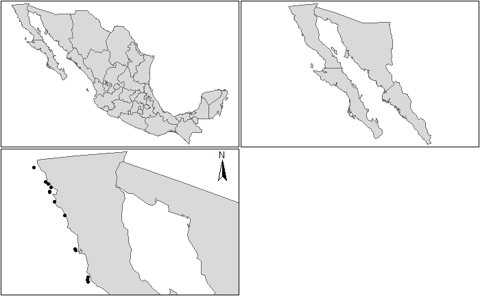

```r
mex_map <- tm_shape(stat) +
  tm_polygons()
pen_map <- tm_shape(baja) +
  tm_polygons()
study_area <- tm_shape(baja, is.master = TRUE, bbox = bb(xlim = c(-117.34240, -112.50193), ylim = c(29.5, 32.72081))) +
  tm_polygons() +
  tm_shape(b) +
  tm_bubbles(size = 0.15, border.col = "black", col = "black", shape = 20) +
  # tm_text("Site", remove.overlap = T) +
  tm_layout(legend.position = c("RIGHT", "TOP")) +
  tm_compass(position = c("RIGHT", "TOP"))
tmap_arrange(mex_map, pen_map, study_area, outer.margins = 0.005)
```

## Sampling

# Results

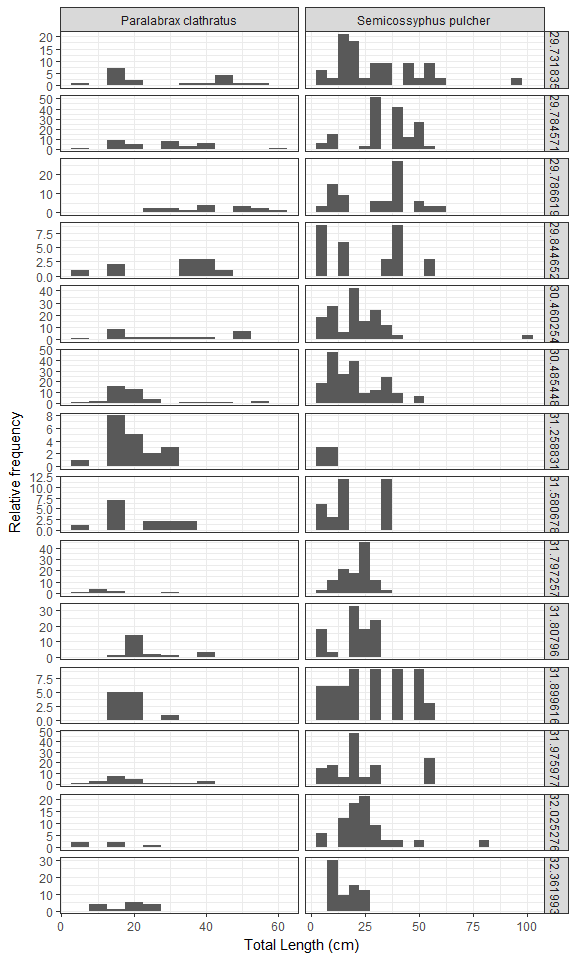

```r
length_data %>%
  filter(GenusSpecies %in% c("Paralabrax clathratus", "Semicossyphus pulcher")) %>%
  reshape::untable(num = .$Abundance) %>%
  mutate(Abundance = 1) %>%
  ggplot(aes(x = Length))+
  geom_histogram(binwidth = 5) +
  facet_grid(Latitude~GenusSpecies, scales = "free") +
  theme_bw() +
  labs(x = "Total Length (cm)", y = "Relative frequency")
```

```r
my_species <- length_data %>%
  reshape::untable(num = .$Abundance) %>%
  mutate(Abundance = 1,
         Fished = ifelse(GenusSpecies %in% c("Paralabrax clathratus", "Semicossyphus pulcher", "Sebastes atrovirens", "Caulolatilus princeps", "Ophiodon elongatus", "Hypsypops rubicundus", "Seriola lalandi", "Paralabrax nebulifer", "Sphyraena argentea"), "1", "0"))
```

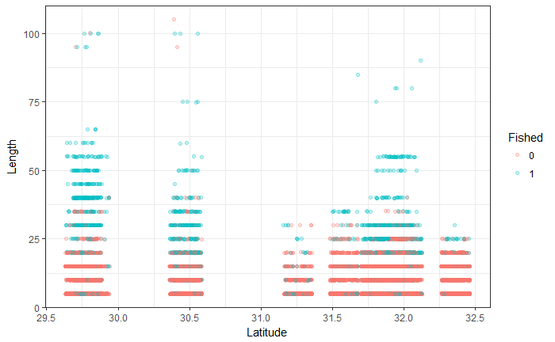

```r
ggplot(my_species, aes(x = Latitude, y = Length, color = Fished)) +
  geom_jitter(alpha = 0.25, height = 0.1, width = 0.1) +
  theme_bw()
```

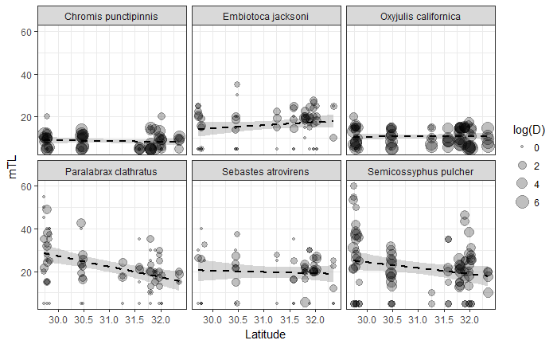

```r
length_data %>%
  filter(GenusSpecies %in% c("Paralabrax clathratus", "Semicossyphus pulcher", "Sebastes atrovirens", "Chromis punctipinnis", "Oxyjulis californica", "Embiotoca jacksoni")) %>%
  reshape::untable(num = .$Abundance) %>%
  mutate(Abundance = 1) %>%
  group_by(Site, Zone, Latitude, KelpDensity, Transect, GenusSpecies) %>%
  summarize(mTL = mean(Length),
            D = sum(Abundance)) %>%
  ungroup() %>%
  ggplot(aes(x = Latitude, y = mTL, size = log(D))) +
  geom_smooth(method = "lm", color = "black", size = 1, linetype = "dashed") +
  geom_point(alpha = 0.25) +
  facet_wrap(~GenusSpecies) +
  theme_bw()
```

```r
lm(Length ~ Latitude * Fished + GenusSpecies, my_species) %>%
  stargazer::stargazer(type = "html")
```

|  | *Dependent variable:* |
| --- | --- |
|  | Length |
| Latitude | -0.497*** |
|  | (0.060) |
| Fished1 | 83.773*** |
|  | (8.583) |
| GenusSpeciesAnisotremus davidsonii | -2.206 |
|  | (3.371) |
| GenusSpeciesArtedius corallinus | -1.066 |
|  | (3.372) |
| GenusSpeciesAtherinops affinis | 4.925** |
|  | (2.199) |
| GenusSpeciesAtherinopsis californiensis | -1.801 |
|  | (5.001) |
| GenusSpeciesBrachyistius frenatus | 2.517 |
|  | (2.169) |
| GenusSpeciesCaulolatilus princeps | 31.143*** |
|  | (6.457) |
| GenusSpeciesChromis punctipinnis | 1.043 |
|  | (2.135) |
| GenusSpeciesClinocottus analis | -0.136 |
|  | (2.876) |
| GenusSpeciesEmbiotoca jacksoni | 11.572*** |
|  | (2.171) |
| GenusSpeciesEmbiotoca lateralis | 9.883*** |
|  | (2.328) |
| GenusSpeciesGibbonsia elegans | -1.909 |
|  | (5.000) |
| GenusSpeciesGirella nigricans | 14.981*** |
|  | (2.253) |
| GenusSpeciesHalichoeres semicinctus | 6.976*** |

[output cut: 82 more lines]

```r
Par <- filter(my_species, GenusSpecies == "Paralabrax clathratus") %>%
  lm(formula = Length ~ Latitude)
Sem <- filter(my_species, GenusSpecies == "Semicossyphus pulcher") %>%
  lm(formula = Length ~ Latitude)
Seb <- filter(my_species, GenusSpecies == "Sebastes atrovirens") %>%
  lm(formula = Length ~ Latitude)
Chr <- filter(my_species, GenusSpecies == "Chromis punctipinnis") %>%
  lm(formula = Length ~ Latitude)
Oxy <- filter(my_species, GenusSpecies == "Oxyjulis californica") %>%
  lm(formula = Length ~ Latitude)
Emb <- filter(my_species, GenusSpecies == "Embiotoca jacksoni") %>%
  lm(formula = Length ~ Latitude)
```

# Discusion and Conclusion

# References